# hichipper QC report

2017-04-27

hichipper, version 0.5.999.

## Sankey Diagrams

Hover your mouse on any edge of the network to see the proportion of PETs that each edge represents. 100 defines the total number of reads originally used as input contained in the `.bam` file while the proportion at the end that is “In Anchors” corresponds to the number of loops.

SRR3928687

[interactive chart not shown]

SRR3928689

[interactive chart not shown]

SRR3928688

[interactive chart not shown]

SRR3928690

[interactive chart not shown]

## Summary Tables

|  | SRR3928687 | SRR3928689 | SRR3928688 | SRR3928690 |
| --- | --- | --- | --- | --- |
| Total PETs | 92540214 | 97058816 | 242406779 | 124750262 |
| % Reads in Anchors | 7.856 | 7.156 | 7.141 | 7.468 |
| % HQ Unique Mapped | 108.468 | 103.064 | 100.371 | 107.091 |
| % Long Range Interaction | 22.385 | 17.256 | 17.612 | 22.034 |
| % in Loops | 0.047 | 0.034 | 0.036 | 0.043 |

|  | SRR3928687 | SRR3928689 | SRR3928688 | SRR3928690 |
| --- | --- | --- | --- | --- |
| Intrachromasomal PETs | 33832128 | 28744887 | 69480955 | 44602451 |
| % Reads &lt; 5Kb | 19.50 | 23.71 | 19.10 | 18.92 |
| % Reads in 5KB-2Mb | 61.23 | 58.27 | 61.45 | 61.63 |
| % Reads &gt; 2Mb | 19.27 | 18.02 | 19.46 | 19.45 |

The second summary table shows the total number of intrachromosomal pets and the distance that they span binned by the max and min user defined distances. Only reads in the middle are used when making loops but all are used for anchor calling. If the very long interactions are disproportionately abundant, the proximity ligation step may not have been effective. In contrast, if the short range interactions are disproportionately abundant, issues with the in situ ligation likely occurred in the experiment.

## Loop Width Distribution Histogram

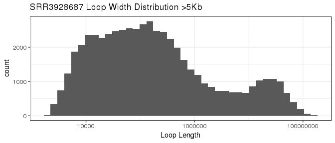

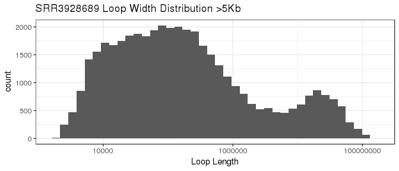

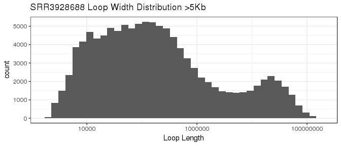

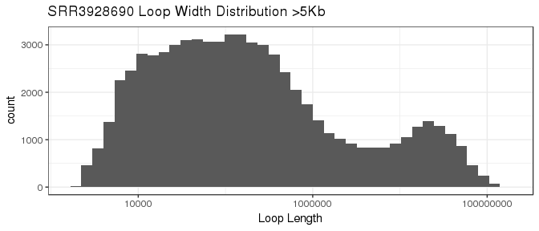

Above is a histogram of the loop widths greater than the minimum distance supplied in the parameters. Note that the loops smaller than the minimum distance have been filtered to make the histogram more interpretable (refer to the table above to see the proportion of very loops below the minimum distance, which are likely self-ligations).

## Raw Read Stats

|  | SRR3928687 | SRR3928689 | SRR3928688 | SRR3928690 |
| --- | --- | --- | --- | --- |
| Total_PETs | 92,540,214 | 97,058,816 | 242,406,779 | 124,750,262 |
| Mapped_unique_quality | 100,376,810 | 100,032,962 | 243,305,284 | 133,596,371 |
| Mapped_unique_quality_valid | 38,695,715 | 32,575,370 | 79,608,166 | 50,932,507 |
| Valid_Intra | 33,832,128 | 28,744,887 | 69,480,955 | 44,602,451 |
| Valid_Intra_&lt;5Kb | 6,598,050 | 6,815,356 | 13,268,063 | 8,438,181 |
| Valid_Intra_5Kb-2Mb | 20,715,288 | 16,748,289 | 42,693,171 | 27,487,158 |
| Valid_Intra_&gt;2Mb | 6,518,790 | 5,181,242 | 13,519,721 | 8,677,112 |
| Valid_Intra_anchor_5Kb-2Mb | 43,777 | 33,313 | 86,264 | 53,344 |
| HQ_Reads_In_Anchors | 7,269,686 | 6,945,211 | 17,310,381 | 9,316,034 |

## Proportional Read Stats

|  | SRR3928687 | SRR3928689 | SRR3928688 | SRR3928690 |
| --- | --- | --- | --- | --- |
| Total_PETs | 100.000 | 100.000 | 100.000 | 100.000 |
| Mapped_unique_quality | 108.468 | 103.064 | 100.371 | 107.091 |
| Mapped_unique_quality_valid | 41.815 | 33.563 | 32.841 | 40.828 |
| Valid_Intra | 36.559 | 29.616 | 28.663 | 35.753 |
| Valid_Intra_&lt;5Kb | 7.130 | 7.022 | 5.473 | 6.764 |
| Valid_Intra_5Kb-2Mb | 22.385 | 17.256 | 17.612 | 22.034 |
| Valid_Intra_&gt;2Mb | 7.044 | 5.338 | 5.577 | 6.956 |
| Valid_Intra_anchor_5Kb-2Mb | 0.047 | 0.034 | 0.036 | 0.043 |
| Long_Range_Interactions | 22.385 | 17.256 | 17.612 | 22.034 |

## Number of Anchor Peaks

| sample | npeaks |
| --- | --- |
| SRR3928687 | 29564 |
| SRR3928689 | 29564 |
| SRR3928688 | 29564 |
| SRR3928690 | 29564 |

The number of anchor peaks used in each sample. In lowly sequenced samples, these numbers may be low and be responsible for the lack of PETs mapping into loops.